# 03 · 后验不确定性与 Bootstrap

## 目标 · Goal

比较两种不同的不确定性计算：给定模型与先验的后验分布，和给定已观察样本的经验重抽样分布。 它们的条件、随机对象和区间解释不同。需要的准备：条件概率、概率密度、分位数。

## 准备 · Setup

先在网页预测结果、拖动参数，再回到这里复算。代码只使用合成数据，不读取学习记录。 所有随机数使用 NumPy PCG64；固定种子可重现本 Notebook，**不意味着与网页的随机样本逐项一致**。 数学定义、参数和边界与网页一致。独立核验脚本另外直接读取网页原始样本，再用 NumPy/SciPy 复算。

运行环境：Python 3.12+，依赖见 `../requirements.txt`。从顶部顺序运行全部单元格；图表标签用英语，讲解用中文。

**Python · cell 3**

```
from pathlib import Path
import sys
candidates = [Path.cwd(), Path.cwd().parent, Path.cwd() / "python"]
source_dir = next((p for p in candidates if (p / "lab_reference.py").is_file()), None)
if source_dir is None:
    raise FileNotFoundError("从 python/notebooks 或 python 目录运行此 Notebook")
sys.path.insert(0, str(source_dir))
import numpy as np
from scipy.stats import norm, beta as beta_distribution
from numpy.polynomial.legendre import legvander
import matplotlib.pyplot as plt
import lab_reference as lab
%matplotlib inline
plt.rcParams.update({"figure.figsize": (9, 4.4), "figure.dpi": 125,
                     "font.size": 11, "axes.spines.top": False,
                     "axes.spines.right": False, "axes.grid": True,
                     "grid.alpha": .18, "axes.axisbelow": True})
BLUE, ORANGE, OLIVE, INK = "#24658c", "#bc6327", "#69743a", "#24323c"
SEED = 42
print("NumPy", np.__version__, "· seed", SEED, "· independent PCG64 draws")
```

```
NumPy 2.5.3 · seed 42 · independent PCG64 draws
```

## 实验 8 · Beta–Binomial 共轭更新

独立 Bernoulli 观测出现 $s$ 次成功、$f$ 次失败。先验 $\theta\sim\mathrm{Beta}(a,b)$ 时，后验为 $\mathrm{Beta}(a+s,b+f)$。 95% 等尾可信区间由后验 CDF 的 0.025 与 0.975 分位数定义；它不是“均值加减两倍标准差”的默认替代品。 似然作为参数的函数不自动是归一化概率密度，本图为便于比较将其峰值归一为 1，并使用独立纵轴。

**Python · cell 5**

```
a,b,success,failure=2,2,7,3
r=lab.compute("bayes",a=a,b=b,success=success,failure=failure)
theta=np.linspace(.0001,.9999,600)
prior=beta_distribution.pdf(theta,a,b); posterior=beta_distribution.pdf(theta,*r["posterior"])
likelihood=theta**success*(1-theta)**failure; likelihood/=likelihood.max()
fig,ax=plt.subplots(figsize=(10,4.8),layout="constrained")
ax.plot(theta,prior,"--",color=ORANGE,label="Prior density")
ax.plot(theta,posterior,color=BLUE,label="Posterior density",linewidth=2)
inside=(theta>=r["interval"][0])&(theta<=r["interval"][1])
ax.fill_between(theta,0,posterior,where=inside,color=BLUE,alpha=.16,label="Central 95% credible region")
second=ax.twinx(); second.plot(theta,likelihood,":",color=OLIVE,label="Likelihood / maximum")
second.set(ylabel="Relative likelihood (peak = 1)",ylim=(0,1.25)); second.grid(False)
ax.set(xlabel="Success probability theta",ylabel="Probability density",title="Beta(2,2) updated by 7 successes and 3 failures")
ax.legend(loc="upper left",fontsize=9); second.legend(loc="upper right",fontsize=9)
plt.show()
print("Posterior parameters:",r["posterior"],"; posterior mean:",round(r["mean"],6))
print("Central 95% credible interval:",np.round(r["interval"],6))
assert np.allclose(beta_distribution.cdf(r["interval"],*r["posterior"]),[.025,.975])
assert lab.compute("bayes",a=1,b=1,success=0,failure=0)["mean"]==.5
```

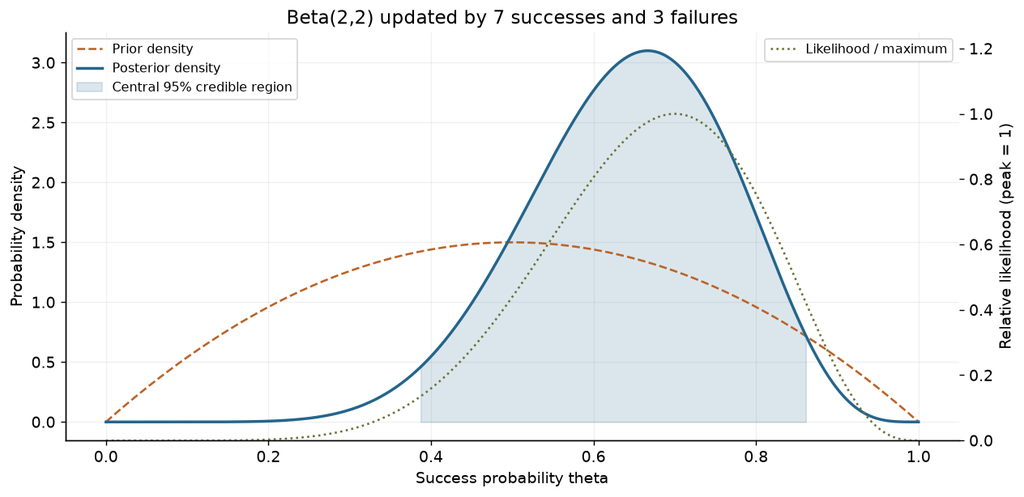

```
Posterior parameters: (9, 5) ; posterior mean: 0.642857
Central 95% credible interval: [0.385738 0.861421]
```

后验密度的纵轴可以大于 1，积分才是概率。右侧相对似然的峰值是人为缩放后的 1。

**自己试：** 用 0 成功、10 失败与均匀先验计算可信区间。为什么区间不应以样本比例 0 为中心做对称扩展？

**核对思路**

后验为 Beta(1,11)，支撑集为 [0,1] 且右偏，等尾分位数自然不对称。

## 实验 12 · Bootstrap 估计的是条件重抽样分布

先抽取一份大小为 $n$ 的样本，再从这份样本有放回抽取 $n$ 个数。重复 $B$ 次计算均值。 Bootstrap 标准误差为这些均值的样本标准差；百分位区间取 2.5% 与 97.5% 分位数，不保证有限样本精确覆盖 95%。 固定样本后，增加 $B$ 只降低模拟噪声，不会增加原始数据的信息。

**Python · cell 8**

```
r=lab.compute("bootstrap",n=30,reps=2000,distribution="exponential",seed=SEED)
fig,axes=plt.subplots(1,2,figsize=(11,4.3),layout="constrained")
axes[0].hist(r["sample"],bins=12,color=ORANGE,edgecolor="white")
axes[0].set(xlabel="Observation",ylabel="Count (n=30)",title="One observed sample from Exp(1)")
axes[1].hist(r["bootstrapMeans"],bins=35,density=True,color=BLUE,alpha=.8,edgecolor="white")
for i,q in enumerate(r["interval"]): axes[1].axvline(q,color=INK,linestyle="--",label="Percentile 95% endpoints" if i==0 else None)
axes[1].axvline(np.mean(r["sample"]),color=ORANGE,linestyle=":",label="Observed sample mean")
axes[1].set(xlabel="Bootstrap sample mean",ylabel="Conditional density estimate",title="2,000 resamples of size 30"); axes[1].legend(fontsize=9)
plt.show()
print("Bootstrap SE:",round(r["bootstrapSE"],6),"; s / sqrt(n):",round(r["analyticSE"],6))
print("Percentile interval:",np.round(r["interval"],6))
# Exact conditional SE of a bootstrap mean uses the empirical variance with divisor n.
exact_conditional=r["sample"].std(ddof=0)/np.sqrt(len(r["sample"]))
print("Exact conditional SE for the empirical distribution:",round(exact_conditional,6))
assert np.array_equal(lab.compute("bootstrap",reps=100)["sample"],lab.compute("bootstrap",reps=2000)["sample"])
```

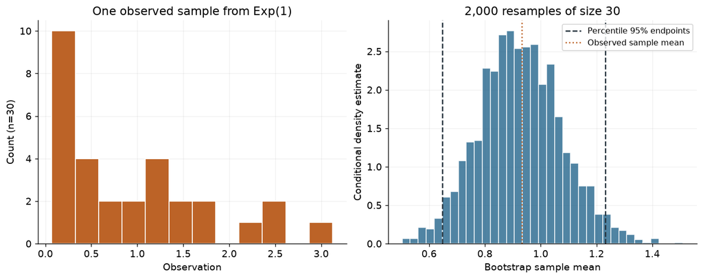

```
Bootstrap SE: 0.148309 ; s / sqrt(n): 0.153985
Percentile interval: [0.647233 1.231548]
Exact conditional SE for the empirical distribution: 0.151397
```

Bootstrap SE 与 $s/\sqrt n$ 不必逐位相等。即使无限重抽样次数，前者对经验分布使用的是分母 $n$ 的方差，后者使用分母 $n-1$；再加上有限重复次数的模拟误差。

**自己试：** 保持种子与 `n` 不变，把 `reps` 改为 100、500、2000。确认原始样本完全相同，再比较区间端点。

## 检查 · Checks

核对了后验区间的精确 CDF 值、无观测时均匀先验的均值、以及改变 Bootstrap 重复次数不会改变原始样本。

## 接下来 · Next steps

用一句话分别回答：可信区间的概率对什么条件化？Bootstrap 分布对什么条件化？为什么它们都不能自动代替前一本中的频率派覆盖率实验？

来源：[SciPy Beta 密度、CDF 和逆 CDF](https://docs.scipy.org/doc/scipy/reference/generated/scipy.stats.beta.html)、[SciPy Bootstrap 方法说明](https://docs.scipy.org/doc/scipy/reference/generated/scipy.stats.bootstrap.html)。本实验采用 percentile 方法，而非该函数默认的 BCa 方法。